# FinalProject

Jonathan Ditch

5/18/2020

We will be using R to download and analyze a dataset.

The tutorial will assume you are using RStudio, which you can get from https://rstudio.com/products/rstudio/download/

To start, we will use a dataset taken from gapminder

To download the dataset, run the following code:

```r
library(tidyverse)
library(readr)
gdp_df <- read_csv("https://raw.githubusercontent.com/jditch/jditch/master/income_per_person_gdppercapita_ppp_inflation_adjusted.csv")
```

Now that we have the dataset, let’s just go ahead and graph it all to visualize what we’ve got

We will use the ggplot() function from the ggplot2 library

Unfortunately, this is made difficult by how ggplot prefers to use a column for an x value, and a column for a y value.

We will use the gather() function to turn each country into “observations” with attributes: country, year, gdp

Here, we will also filter our data to only include observations from 2005 to 2019

```r
gdp_tall <- gdp_df %>%
  gather("year", "gdp", -country) %>%
  filter(year %in% 2005:2019) %>%
  mutate(year = as.integer(year))

gdp_tall
```

```
## # A tibble: 2,895 x 3
##    country              year   gdp
##    <chr>               <int> <dbl>
##  1 Afghanistan          2005  1100
##  2 Albania              2005  7430
##  3 Algeria              2005 12400
##  4 Andorra              2005 39800
##  5 Angola               2005  5110
##  6 Antigua and Barbuda  2005 22200
##  7 Argentina            2005 15600
##  8 Armenia              2005  5360
##  9 Australia            2005 39000
## 10 Austria              2005 41300
## # ... with 2,885 more rows
```

Now that we have our data ready to go, let’s graph it with:

x values corresponding to year

y values corresponting to gdp

groupping by country (for the creation of a line plot)

Due to how much space a legend identifying the colors would take up, we will simply remove it

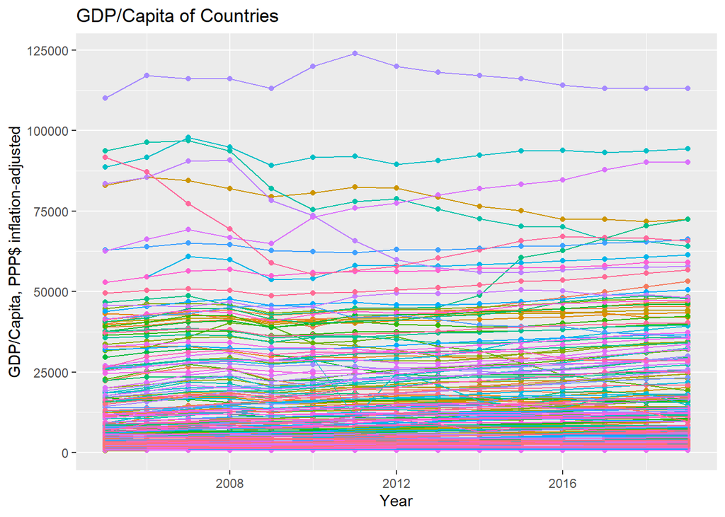

```r
library(ggplot2)
gdp_tall %>%
ggplot(mapping=aes(x=year, y=gdp, group = country, color = country))+
    geom_point() +
    geom_line(method="lm", se=FALSE) +
  labs(title="GDP/Capita of Countries",
       x="Year",
       y="GDP/Capita, PPP$ inflation-adjusted") +
  theme(legend.position="none")
```

Well, that’s a mess to look at. Let’s just look at the graphs for the Some countries we are familiar with

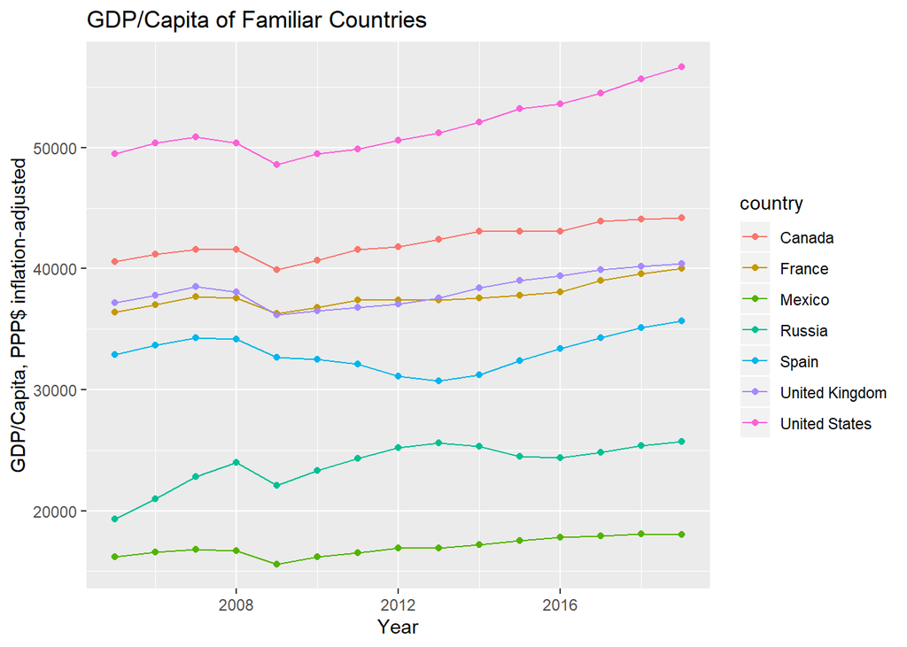

```r
gdp_tall %>%
  ggplot(data = subset(gdp_tall, country %in% c("United States", "Mexico", "Canada" , "United Kingdom", "France", "Spain", "Russia")),
         mapping=aes(x=year, y=gdp, group = country, color = country))+
    geom_point() +
    geom_line(method="lm", se=FALSE) +
    labs(title="GDP/Capita of Familiar Countries",
       x="Year",
       y="GDP/Capita, PPP$ inflation-adjusted")
```

We can make sense of this with fewer elements cluttering the graph. We can even see a fall in GDP from the 2008 recession

We can also see that with each passing year, the gdp tends to increase

Do other countries have this increasing trend? This is where we can use linear regression to get a line of best fit for gdp values

First, let’s look at how a line of best fit would look on each of the familiar countries we looked at before, just so we can visualize how the linear regression works

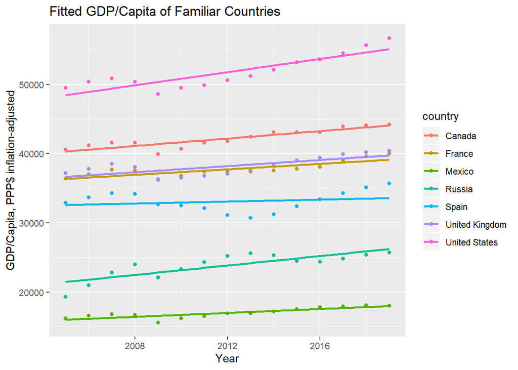

```r
gdp_tall %>%
  ggplot(data = subset(gdp_tall, country %in% c("United States", "Mexico", "Canada" , "United Kingdom", "France", "Spain", "Russia")),
         mapping=aes(x=year, y=gdp, group = country, color = country))+
    geom_point() +
    geom_smooth(method="lm", se=FALSE) +
    labs(title="Fitted GDP/Capita of Familiar Countries",
       x="Year",
       y="GDP/Capita, PPP$ inflation-adjusted")
```

These lines all follow the trend of the data from the countries they are tied to, and all of the lines are increasing, affirming our previous observation of an increasing trend in the gdp each year

```r
library(broom)
gdp.lm = lm(formula = gdp ~ year, data=gdp_tall)

gdp.lm %>%
  tidy()
```

```
## # A tibble: 2 x 5
##   term        estimate std.error statistic p.value
##   <chr>          <dbl>     <dbl>     <dbl>   <dbl>
## 1 (Intercept) -304841.  167667.      -1.82  0.0691
## 2 year            160.      83.3      1.92  0.0548
```

According to this data, gdp, as plotted across all countries, increases at around 160 per year

For those of you taking algebra, the line created by this would be y = -304841.2129 + 160.1051 * x if you wanted to put it into a graphing calculator

Note the p-value for the year is slightly over 0.05. This means the estimation is not statistically significant i.e. The data does not follow this trend perfectly

We can also do this with ggplot to visuallise our line of best fit

```r
library(broom)
ggplot
```

[output not shown]

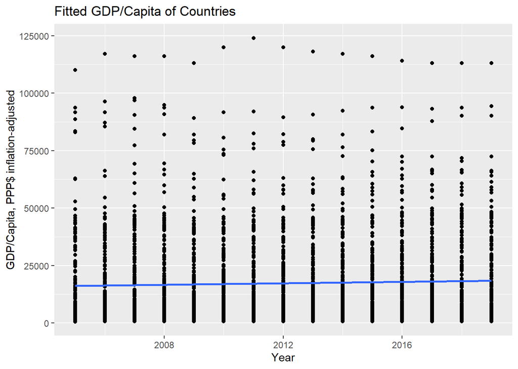

```r
gdp_tall %>%
  ggplot(mapping=aes(x=year, y=gdp))+
    geom_point() +
    geom_smooth(method="lm", se = FALSE) +
    labs(title="Fitted GDP/Capita of Countries",
       x="Year",
       y="GDP/Capita, PPP$ inflation-adjusted")
```

Notice how there are a lot of data points that are very far from our line. We can remedy this by centering each country’s mean value on 0

Essentially, we take the mean GDP of across all years, and subtract each of the country’s gdp values by that mean

```r
gdp_adjusted_df <- gdp_tall %>%
  group_by(country) %>%
  mutate(mean_gdp = mean(gdp)) %>%
  mutate(adjusted_gdp = (gdp - mean_gdp) ) %>%
  ungroup()
gdp_adjusted_df
```

```
## # A tibble: 2,895 x 5
##    country              year   gdp mean_gdp adjusted_gdp
##    <chr>               <int> <dbl>    <dbl>        <dbl>
##  1 Afghanistan          2005  1100    1581.        -481.
##  2 Albania              2005  7430   10227.       -2797.
##  3 Algeria              2005 12400   13213.        -813.
##  4 Andorra              2005 39800   44653.       -4853.
##  5 Angola               2005  5110    6169.       -1059.
##  6 Antigua and Barbuda  2005 22200   22607.        -407.
##  7 Argentina            2005 15600   18353.       -2753.
##  8 Armenia              2005  5360    7564        -2204
##  9 Australia            2005 39000   42640        -3640
## 10 Austria              2005 41300   44240        -2940
## # ... with 2,885 more rows
```

Now if we try to graph a regression line, it looks like this:

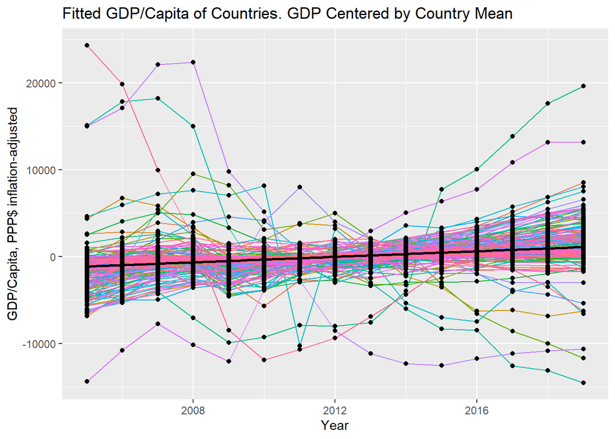

```r
gdp_adjusted_df %>%
  ggplot(mapping=aes(x=year, y=adjusted_gdp))+
    geom_line(mapping=aes(x=year, y=adjusted_gdp, group = country, color = country), method="lm", se=FALSE) +
    geom_point() +
    geom_smooth(method="lm", se = FALSE, color = 'black') +
    labs(title="Fitted GDP/Capita of Countries. GDP Centered by Country Mean",
       x="Year",
       y="GDP/Capita, PPP$ inflation-adjusted")+
  theme(legend.position="none")
```

The black line running through the clusters of points is our line of best fit

Notice how we still have values that our outliers. These come from countries that have have more volatile differences in GDP from year to year

We can standardize the values by dividing each value by the country’s standard deviation, which is derived from all gdp observations from the country

```r
gdp_standardized_df <- gdp_tall %>%
  group_by(country) %>%
  mutate(mean_gdp = mean(gdp)) %>%
  mutate(sd_gdp = sd(gdp)) %>%
  mutate(z_gdp = (gdp - mean_gdp) / sd_gdp) %>%
  ungroup()
gdp_standardized_df
```

```
## # A tibble: 2,895 x 6
##    country              year   gdp mean_gdp sd_gdp  z_gdp
##    <chr>               <int> <dbl>    <dbl>  <dbl>  <dbl>
##  1 Afghanistan          2005  1100    1581.   262. -1.84
##  2 Albania              2005  7430   10227.  1541. -1.82
##  3 Algeria              2005 12400   13213.   588. -1.38
##  4 Andorra              2005 39800   44653.  4298. -1.13
##  5 Angola               2005  5110    6169.   504. -2.10
##  6 Antigua and Barbuda  2005 22200   22607.  2127. -0.191
##  7 Argentina            2005 15600   18353.  1158. -2.38
##  8 Armenia              2005  5360    7564   1165. -1.89
##  9 Australia            2005 39000   42640   2075. -1.75
## 10 Austria              2005 41300   44240   1446. -2.03
## # ... with 2,885 more rows
```

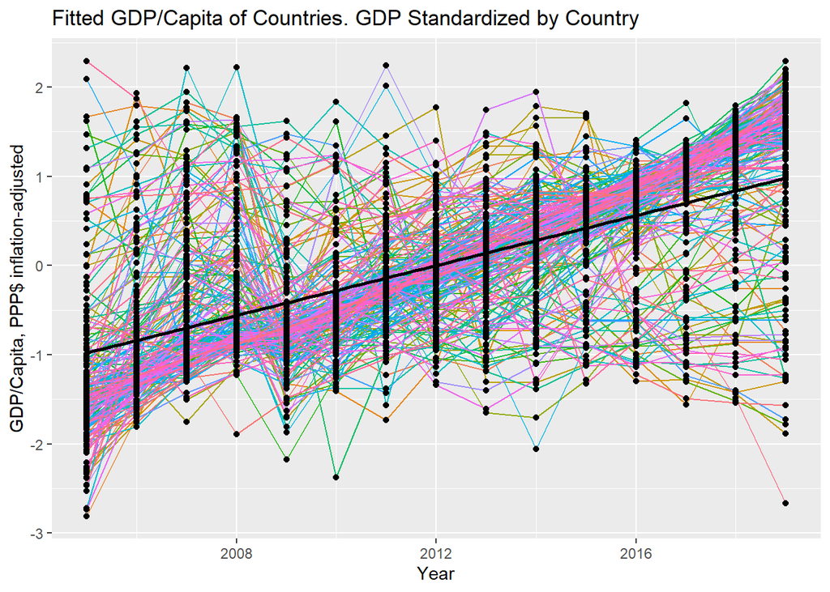

```r
gdp_standardized_df %>%
  ggplot(mapping=aes(x=year, y=z_gdp))+
    geom_line(mapping=aes(x=year, y=z_gdp, group = country, color = country), method="lm", se=FALSE) +
    geom_point() +
    geom_smooth(method="lm", se = FALSE, color = 'black') +
    labs(title="Fitted GDP/Capita of Countries. GDP Standardized by Country",
       x="Year",
       y="GDP/Capita, PPP$ inflation-adjusted") +
  theme(legend.position="none")
```

With the data standardized, our data points are more uniformly distributed, and it becomes more obvious that there is a general increasing trend in GDP

However, we completely lose any sense of the scale of our data, as a range of 2 to -3 does not really correspond well to GDP